← saditahmid.github.io Mohammed Tahmid Hossain

EDA · Climate Correlation · IEEE TENCON 2023

# Understanding the Dynamics of Dengue in Bangladesh

Exploratory analysis of dengue case data across divisions and years — seasonal transmission windows, regional burden, and climate correlation, reproducing the analysis behind the published paper.

PythonPandasSeabornEDAClimate Data

EXPLORATORY DATA ANALYSIS

# Dengue Dynamics in Bangladesh

A longitudinal analysis of dengue fever across 8 divisions of Bangladesh (2014–2022), examining epidemic trends, seasonal transmission windows, regional disparities, and the correlation between climate variables and outbreak intensity.

🗺️ 8 Divisions 📅 2014 – 2022 🦟 822 Records 🐍 Python · Pandas · Seaborn

## 📌 Background & Context

Dengue fever is a mosquito-borne viral infection transmitted primarily by *Aedes aegypti*. Bangladesh has experienced increasingly severe outbreaks over the past decade, with the **2019 epidemic** marking a turning point — over 100,000 reported cases in a single year, overwhelming the country's healthcare system.

Dengue transmission is tightly coupled to **climate**: warm temperatures accelerate the mosquito life cycle, while rainfall creates the standing-water breeding sites *Aedes* mosquitoes depend on. Understanding these dynamics is essential for early-warning systems and targeted vector control.

This analysis explores a merged dataset of monthly dengue case counts and climate readings across all 8 administrative divisions of Bangladesh.

> **Data sources:** Case data — Ministry of Health & Family Welfare (Bangladesh). Climate data — web-scraped divisional weather records. *Companion analysis to IEEE TENCON 2023 publication.*

## 📋 Table of Contents

1. Setup & Configuration
2. Data Loading & First Look
3. Data Preparation
4. Exploratory Data Analysis
   - 4.1 Overview Statistics
   - 4.2 Annual Epidemic Trend
   - 4.3 Seasonal Transmission Window
   - 4.4 Regional Distribution
   - 4.5 Seasonal Heatmap (Month × Division)
   - 4.6 Climate Correlation
   - 4.7 Cases vs Deaths
   - 4.8 Outlier Handling — Raw vs Resampled
   - 4.9 Geographic Spread Over Time
5. Key Findings

## 1. Setup & Configuration

```
✅ Setup complete.
```

## 2. Data Loading & First Look

```
Shape   : 822 rows × 8 columns
Columns : ['Date', 'Region', 'Avg Temperature', 'Avg Humidity', 'Avg Precipitation', 'Total_Case', 'Total_Death', 'Region_Encode']
```

|  | Date | Region | Avg Temperature | Avg Humidity | Avg Precipitation | Total_Case | Total_Death | Region_Encode |
| --- | --- | --- | --- | --- | --- | --- | --- | --- |
| 0 | 2014-01-31 | Barishal | 21.322581 | 51.838710 | 0.000000 | 0.0 | 0.0 | 7 |
| 1 | 2014-02-28 | Barishal | 23.857143 | 50.821429 | 0.042857 | 0.0 | 0.0 | 7 |
| 2 | 2014-03-31 | Barishal | 28.451613 | 50.000000 | 0.054839 | 0.0 | 0.0 | 7 |
| 3 | 2014-04-30 | Barishal | 33.066667 | 57.933333 | 0.010000 | 0.0 | 0.0 | 7 |
| 4 | 2014-05-31 | Barishal | 32.741935 | 67.000000 | 0.448387 | 0.0 | 0.0 | 7 |
| 5 | 2014-06-30 | Barishal | 32.100000 | 72.533333 | 1.503333 | 0.0 | 0.0 | 7 |
| 6 | 2014-07-31 | Barishal | 30.516129 | 78.322581 | 1.645161 | 0.0 | 0.0 | 7 |
| 7 | 2014-08-31 | Barishal | 29.483871 | 81.741935 | 1.725806 | 0.0 | 0.0 | 7 |

```
=== Column Summary ===
<class 'pandas.DataFrame'>
RangeIndex: 822 entries, 0 to 821
Data columns (total 8 columns):
 #   Column             Non-Null Count  Dtype
---  ------             --------------  -----
 0   Date               822 non-null    str
 1   Region             822 non-null    str
 2   Avg Temperature    822 non-null    float64
 3   Avg Humidity       822 non-null    float64
 4   Avg Precipitation  822 non-null    float64
 5   Total_Case         805 non-null    float64
 6   Total_Death        805 non-null    float64
 7   Region_Encode      822 non-null    int64
dtypes: float64(5), int64(1), str(2)
memory usage: 65.4 KB

=== Missing values ===
Date                  0
Region                0
Avg Temperature       0
Avg Humidity          0
Avg Precipitation     0
Total_Case           17
Total_Death          17
Region_Encode         0
dtype: int64
```

## 3. Data Preparation

The dataset is already fairly clean. We parse dates, sort chronologically, add month/year helper columns, and confirm the divisional coverage.

```
══════════════════════════════════════════════
  DATASET SUMMARY
══════════════════════════════════════════════
  Records        : 822
  Divisions      : 8  (Barishal, Chittagong, Dhaka, Khulna, Mymensingh, Rajshahi, Rangpur, Sylhet)
  Date range     : 2014-01-31  →  2022-12-31
  Total cases    : 216,040
  Total deaths   : 742
  Case-fatality  : 0.34%
══════════════════════════════════════════════
```

## 4. Exploratory Data Analysis

### 4.1 Overview Statistics

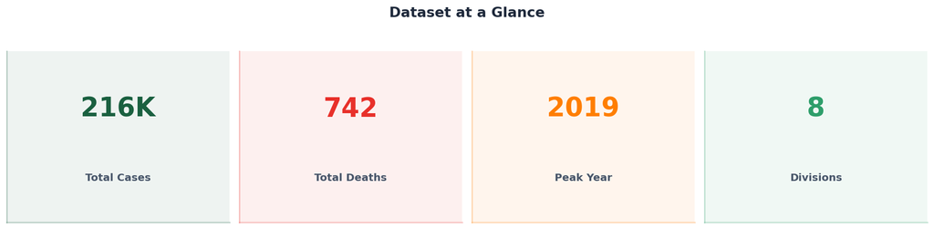

|  | Avg Temperature | Avg Humidity | Avg Precipitation | Total_Case | Total_Death |
| --- | --- | --- | --- | --- | --- |
| count | 822.0 | 822.0 | 822.0 | 805.0 | 805.0 |
| mean | 28.0 | 65.9 | 4.1 | 268.4 | 0.9 |
| std | 3.9 | 13.4 | 6.3 | 1588.6 | 6.2 |
| min | 17.6 | 28.8 | 0.0 | 0.0 | -1.0 |
| 25% | 24.9 | 55.0 | 0.2 | 0.0 | 0.0 |
| 50% | 29.0 | 68.9 | 1.9 | 0.0 | 0.0 |
| 75% | 30.8 | 76.9 | 5.2 | 13.0 | 0.0 |
| max | 37.0 | 98.0 | 49.8 | 32008.0 | 124.0 |

### 4.2 Annual Epidemic Trend

Total reported dengue cases per year reveal the explosive, episodic nature of dengue in Bangladesh — long quiet periods punctuated by catastrophic epidemic years.

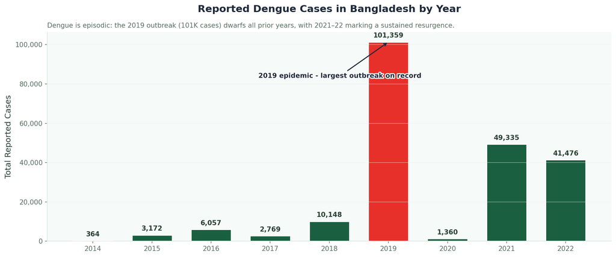

### 4.3 Seasonal Transmission Window

[figure not shown]

### 4.4 Regional Distribution

Dengue burden is highly unequal across divisions. Dhaka — the densely populated capital — bears the overwhelming majority of cases.

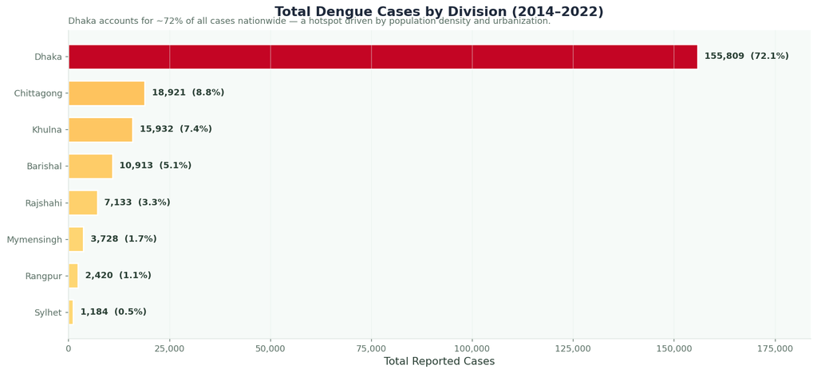

### 4.5 Seasonal Heatmap — Month × Division

Combining the seasonal and regional views into a single heatmap shows *where* and *when* dengue concentrates.

[figure not shown]

### 4.6 Climate Correlation

Do climate variables track dengue incidence? We examine pairwise correlations between temperature, humidity, precipitation, and case counts.

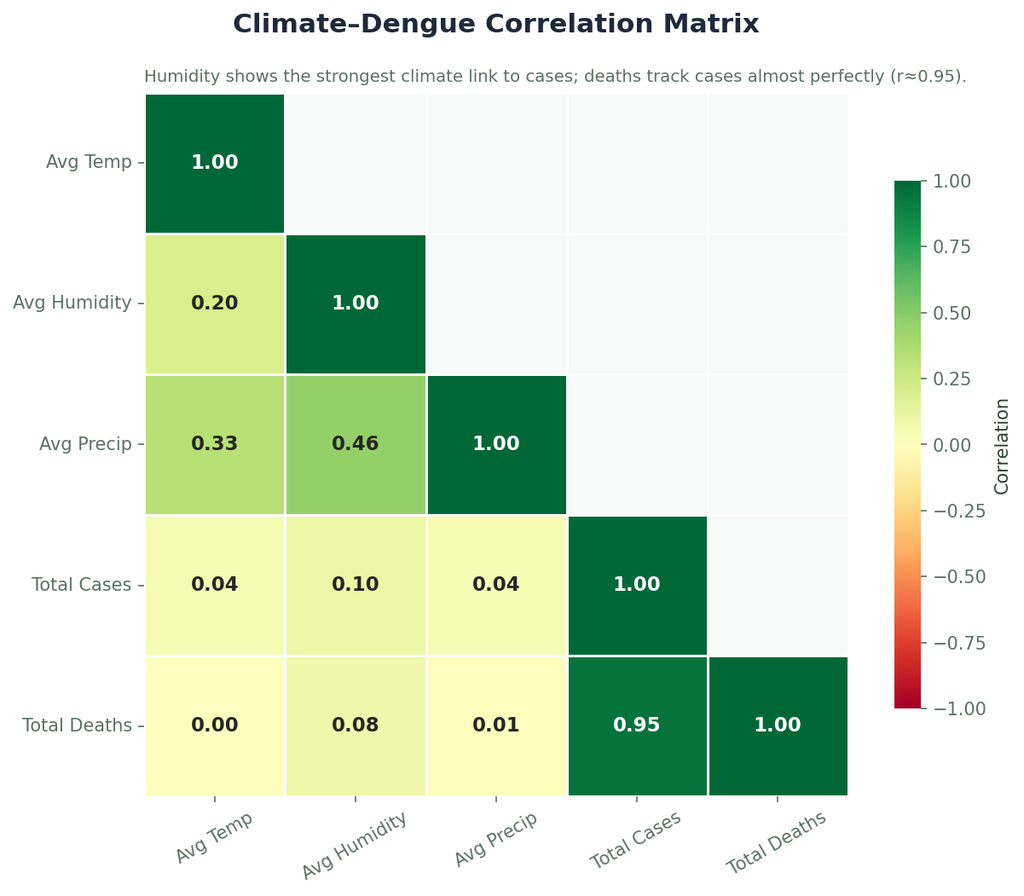

### 4.7 Cases vs Deaths Over Time

Plotting the national monthly time series of cases against deaths shows how mortality tracks caseload — and highlights the human cost of each epidemic wave.

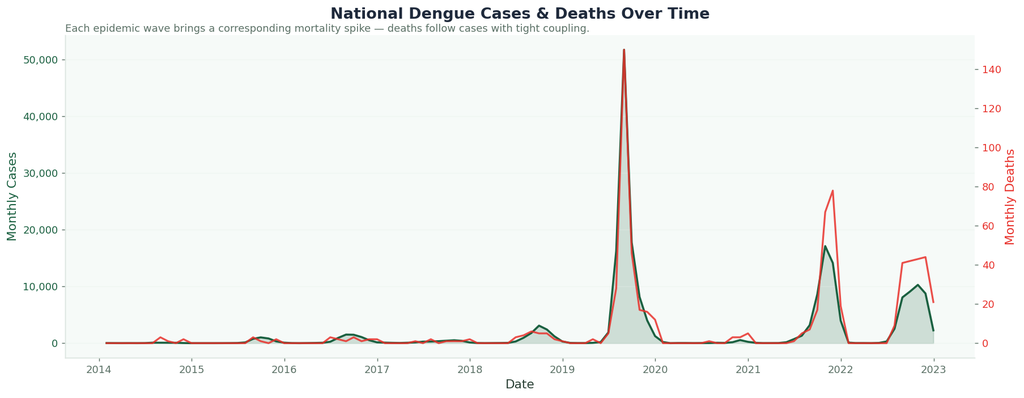

### 4.8 Outlier Handling — Raw vs Resampled

Epidemic years (2019, 2021, 2022) contain extreme case spikes that can dominate a model and obscure the underlying seasonal signal. The paper mitigates this by **resampling** — replacing outlier-year values with the baseline monthly average from non-epidemic years. This visual compares the raw and resampled national time series.

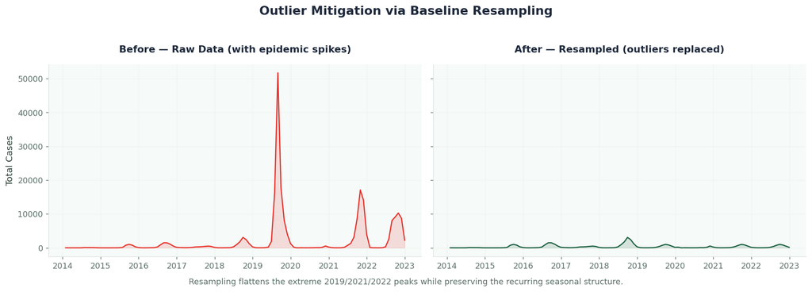

### 4.9 Geographic Spread Over Time

A choropleth map animated year-by-year (2014–2022) shows *where* dengue concentrates geographically and how the burden shifts across Bangladesh's divisions during epidemic years. Dhaka consistently dominates, but the 2019 and 2021–22 outbreaks show visible spread into surrounding divisions.

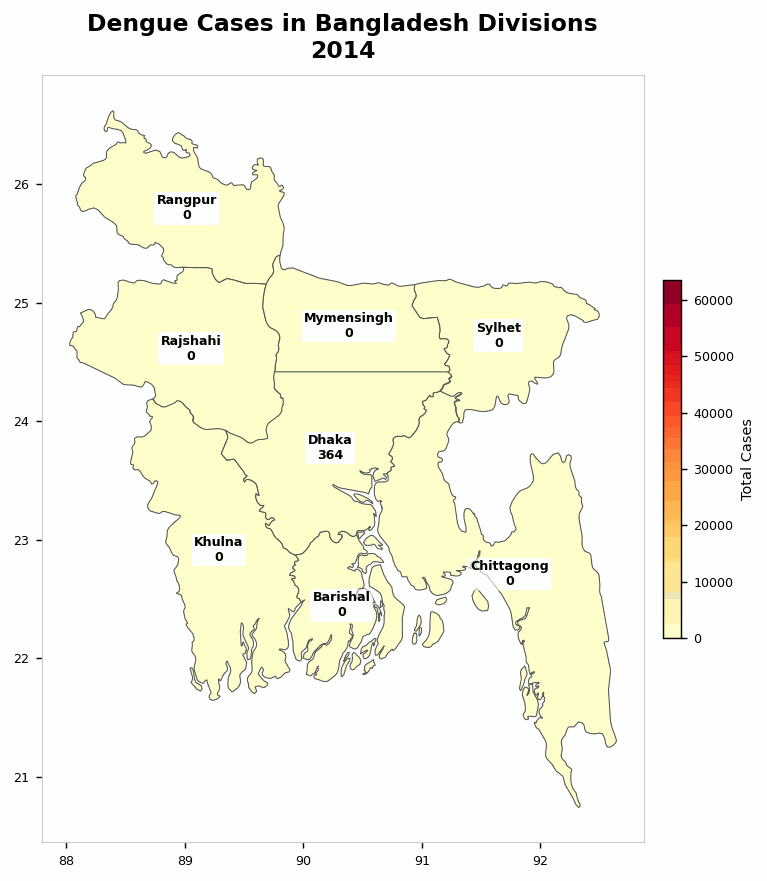

## 5. Key Findings

### 🦟 1. Dengue is Episodic, Not Steady

Cases stayed under 11K/year through 2018, then exploded to **101K in 2019** — the largest outbreak on record. After a COVID-suppressed 2020, dengue resurged strongly in 2021–22, suggesting a troubling shift toward sustained high transmission.

### 🏙️ 2. Dhaka is the National Epicenter

The capital division accounts for roughly **72% of all reported cases** despite being one of 8 divisions. High population density, rapid urbanization, and abundant *Aedes* breeding sites concentrate the burden here.

### 💧 4. Humidity is the Strongest Climate Signal

Among climate variables, **humidity** correlates most with case counts. Temperature and precipitation show weaker direct linear correlation — likely because their effect is lagged and non-linear rather than contemporaneous.

### ⚰️ 5. Mortality Tracks Caseload Tightly

Deaths correlate with cases at **r ≈ 0.95**. Each epidemic wave carries a proportional mortality cost, underscoring that outbreak prevention — not just treatment capacity — is the key lever for reducing deaths.

### 🗺️ 6. The Burden is Geographically Concentrated but Spreading

The year-by-year map reveals that while Dhaka is the persistent epicenter, epidemic years (2019, 2021–22) show dengue **spreading outward** into previously low-burden divisions like Chittagong and Khulna — a warning sign that transmission is no longer confined to the capital.

*Analysis by Mohammed Tahmid Hossain · saditahmid.github.io · Related publication: IEEE TENCON 2023*

Full analysis · reproducible notebook on [GitHub](https://github.com/saditahmid/PortfolioProjects/blob/master/Dengue_EDA/Dengue_Bangladesh_EDA.ipynb) ← back to projects